# Prevention is Better than Cure—Statistical Observations of Cardiovascular Disease Data

Ty Kentaro Okazaki, Matthew R Herradura, David Xie, Carson Klein

2021-12-12

## Introduction

Cardiovascular disease susceptibility and related hospitalizations is a crucial topic of research because it is intertwined with our lifestyle and consequent life expectancy. From statistical data provided by [*Centers for Disease Control and Prevention (CDC)*](https://www.cdc.gov/heartdisease/facts.htm), it shows that **one person dies every 36 seconds** in the United States from cardiovascular disease; furthermore, about 659,000 people in United States die from heart diseases, which is about 1 in every four deaths. Considering the emerging epidemic that is cardiovascular disease in the developing world, having adequate treatments are essential to reducing symptoms and mortality. However, treatments for cardiovascular disease are expensive, lengthy, are often not adequate to helping patients in need. In order to fight this emerging epidemic, it is essential to educate individuals on the factors that increases their susceptibility for cardiovascular disease. Likewise, since cardiovascular disease is so dangerously common, it interests us to discover more about cardiovascular disease’s relationship between predictor variables, such as location, age, race, and gender.

Using data gathered from Medicare and Medicaid patients, the Center for Medicare & Medicaid services (CMS) compiles claim data across numerous categorical and numerical variables. Collected from a variety of sources including: hospital databases, diagnostic reports, and surveys whilst adhering to an array of Quality Rating System (QRS) guidelines and requirements, the Center for Medicare & Medicaid services provides reliable and representative data. Computed by personnel in CDC’s Division for Heart Disease and Stroke Prevention (DHDSP), furthermore, this [data set](https://chronicdata.cdc.gov/Heart-Disease-Stroke-Prevention/Center-for-Medicare-Medicaid-Services-CMS-Medicare/iw6q-r3ja) provides potential insights on Cardiovascular disease (CVD) indicators and associated risk factors; categorized by variables such as age, race/ethnicity, and location, this data set can be processed and analyzed using statistical methods to highlight insights into CVD prevention. Specifically, this data set includes anonymous CVD hospitalizations data from Medicare & Medicaid patients of age 65+ across the United States. Considering the influences and patterns variables can have with regard to predicting CVD hospitalization instances, it is important to dissect and analyze those of paramount importance. Consequently, our general research question(s) are as follows: What are the main factors that influence a patient’s susceptibility for developing cardiovascular disease and hospitalization rates? Is there a significant relationship between specific variables and the prevalence of cardiovascular disease and hospitalization rates?

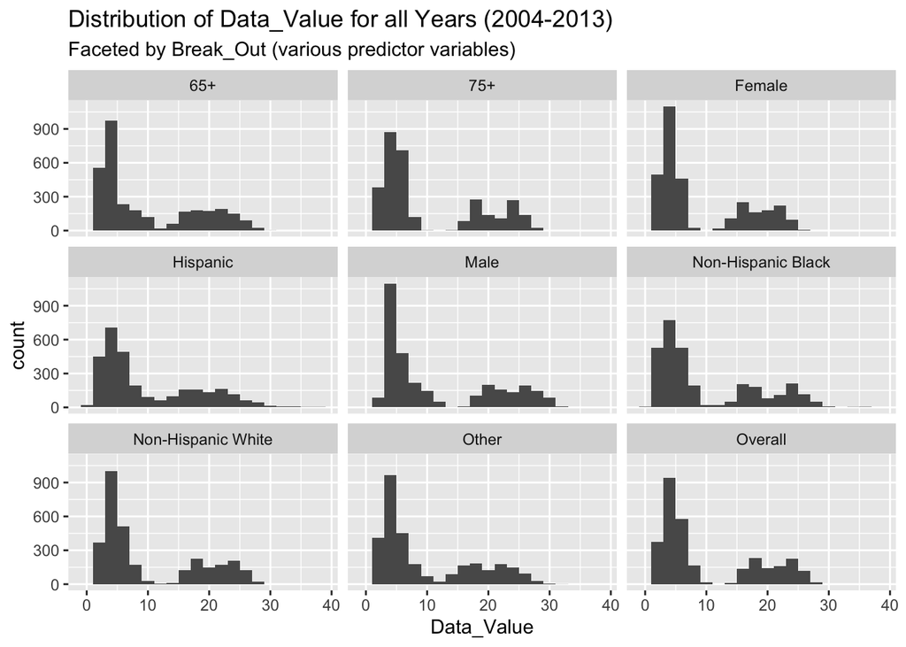

#### Code Book

This data set includes instances of cardiovascular disease (CVD), potential indicators, and associated risk factors for Medicare and Medicaid patients across the United States.

Dimensions of the `cms_data` data frame (after cleaning).

- Rows/Observations: 42,640
- Columns/Variables: 16

A description of the variables is below:

| Variable Name | Description | Data Type |
| --- | --- | --- |
| `Year` | Year | Number |
| `LocationAbbr` | Location abbreviation | Plain Text |
| `PriorityArea1` | Priority Area (Million Hearts® or None) | Plain Text |
| `PriorityArea2` | Priority Area (ABCS or None) | Plain Text |
| `PriorityArea3` | Priority Area (Healthy People 2020 or None) | Plain Text |
| `PriorityArea4` | Priority Area (AHA 2020 Goals: Cardiovascular Health Metrics or None) | Plain Text |
| `Topic` | Topic description | Plain Text |
| `Indicator` | Indicator description | Plain Text |
| `Data_Value_Unit` | Data Value Unit (%, rate per 100,000, etc.) | Plain Text |
| `Data_Value` | Data value (point estimate) | Number |
| `LowConfidenceLimit` | 95% confidence interval lower bound | Number |
| `HighConfidenceLimit` | 95% confidence interval upper bound | Number |
| `Break_Out_Category` | Break out category description | Plain Text |
| `Break_Out` | Break out group description | Plain Text |
| `LocationId` | Location lookup value | Plain Text |
| `GeoLocation` | Latitude & Longitude to be provided for formatting GeoLocation or Geocode in the format (latitude, longitude) | Location |

## Analysis

In this section, we will analyze the data to address various research questions

### How is race related to Cardiovascular Disease and Hospitalizations?

```
## # A tibble: 4 × 5
##   Break_Out          mean_value median_value iqr_value sd_value
##   <chr>                   <dbl>        <dbl>     <dbl>    <dbl>
## 1 Hispanic                 25.7         20.4      18.9     20.8
## 2 Non-Hispanic Black       32.4         30.1      16.0     15.0
## 3 Non-Hispanic White       21.4         17.8      15.8     14.2
## 4 Other                    21.7         16.2      15.8     17.1
```

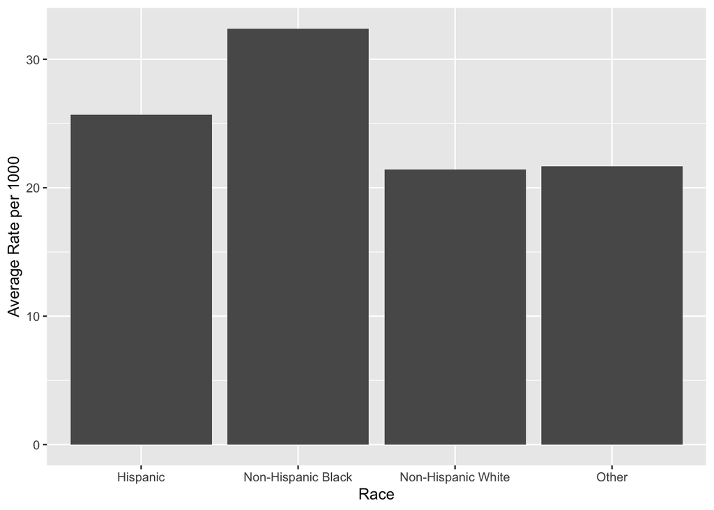

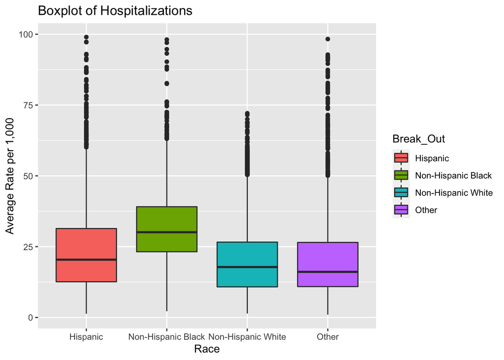

From looking at preliminary statistics and visuals, relationships between the rate of major cardiovascular disease hospitalizations can be seen among different races in the United States. From the data, it shows that Hispanics and Non-Hispanic Black individuals face more hospitalizations in comparison to Non-Hispanic white individuals. Looking at the data collected from 2004 - 2013, on average, about 25.6620708 (per 1000 people) Hispanic individuals are hospitalized for cardiovascular diseases while 32.3926941 Non-Hispanic African Americans are hospitalized for the same reasons. These rates are considerably higher in comparison to the rate of White Americans per 1000 people where only about 21.4052885 individuals are hospitalized. This means that per 1000 people, about 10.9874056 more African Americans and 4.2567824 more Hispanics normally find themselves affected by cardiovascular disease.

#### **How much more affected by Cardiovascular Disease Hospitalizations are Hispanics and Non-Hispanic Black individuals compared to Non-Hispanic Whites?**

**Null Hypothesis: Being a Hispanic or Non-Hispanic Black individual does not increase the risk of being hospitalized for Cardiovascular Disease in the US.**

**Alternative Hypothesis: Being a Hispanic or Non-Hispanic Black individual does increase the risk of being hospitalized for Cardiovascular Disease in the US.**

```
## # A tibble: 6 × 6
## # Groups:   LocationAbbr [2]
##   LocationAbbr Break_Out           mean median in_south in_west
##   <chr>        <chr>              <dbl>  <dbl> <chr>    <chr>
## 1 AK           Hispanic            27.7   19.6 no       yes
## 2 AK           Non-Hispanic Black  22.3   16   no       yes
## 3 AK           Non-Hispanic White  14.0   12.2 no       yes
## 4 AK           Other               14.1   11.5 no       yes
## 5 AL           Hispanic            24.6   20   yes      no
## 6 AL           Non-Hispanic Black  34.2   32.3 yes      no
```

```
## Response: Data_Value (numeric)
## Explanatory: Break_Out (factor)
## # A tibble: 6 × 2
##   replicate  stat
##       <int> <dbl>
## 1         1 10.3
## 2         2 10.7
## 3         3 11.6
## 4         4  9.92
## 5         5 11.9
## 6         6 10.9
```

```
## Using `level = 0.95` to compute confidence interval.
```

```
## # A tibble: 1 × 2
##   lower_ci upper_ci
##      <dbl>    <dbl>
## 1     10.2     11.9
```

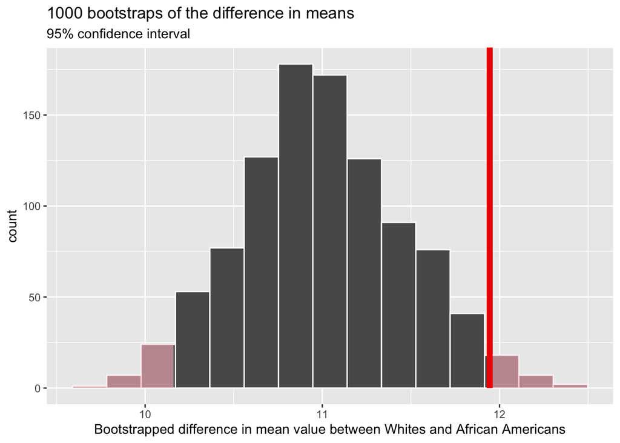

```
## Response: Data_Value (numeric)
## Explanatory: Break_Out (factor)
## # A tibble: 6 × 2
##   replicate  stat
##       <int> <dbl>
## 1         1  4.09
## 2         2  4.66
## 3         3  4.20
## 4         4  4.01
## 5         5  4.10
## 6         6  3.22
```

```
## Using `level = 0.95` to compute confidence interval.
```

```
## # A tibble: 1 × 2
##   lower_ci upper_ci
##      <dbl>    <dbl>
## 1     3.09     5.41
```

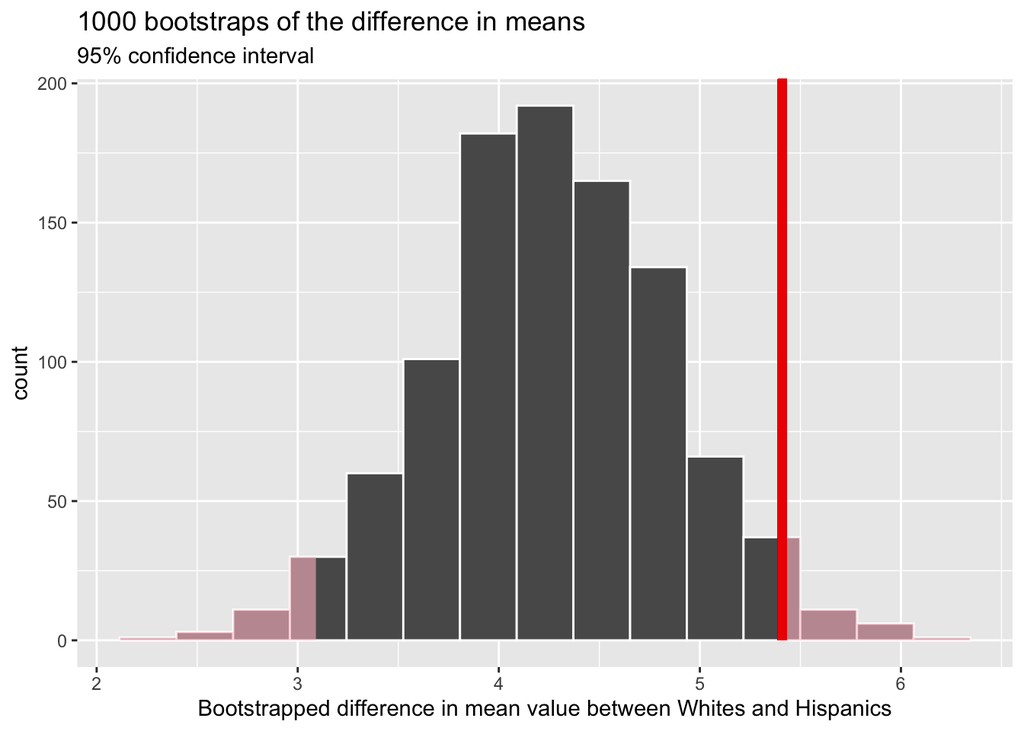

#### Can we predict the rate of Hospitalizations for people of different races based on their location?

```
## # A tibble: 3 × 5
##   term                        estimate std.error statistic   p.value
##   <chr>                          <dbl>     <dbl>     <dbl>     <dbl>
## 1 (Intercept)                    34.0      0.339     100.  0
## 2 Break_OutNon-Hispanic White   -10.9      0.447     -24.4 7.22e-123
## 3 in_west                        -7.89     0.552     -14.3 2.51e- 45
```

```
## # A tibble: 3 × 5
##   term                        estimate std.error statistic   p.value
##   <chr>                          <dbl>     <dbl>     <dbl>     <dbl>
## 1 (Intercept)                    31.0      0.362     85.8  0
## 2 Break_OutNon-Hispanic White   -10.9      0.454    -24.1  1.27e-119
## 3 in_south                        4.20     0.488      8.60 1.13e- 17
```

```
## # A tibble: 3 × 5
##   term                        estimate std.error statistic  p.value
##   <chr>                          <dbl>     <dbl>     <dbl>    <dbl>
## 1 (Intercept)                    27.3      0.429     63.5  0
## 2 Break_OutNon-Hispanic White    -4.26     0.555     -7.67 2.20e-14
## 3 in_west                        -7.62     0.678    -11.2  7.81e-29
```

```
## # A tibble: 3 × 5
##   term                        estimate std.error statistic  p.value
##   <chr>                          <dbl>     <dbl>     <dbl>    <dbl>
## 1 (Intercept)                    24.6      0.452     54.3  0
## 2 Break_OutNon-Hispanic White    -4.22     0.562     -7.51 7.24e-14
## 3 in_south                        3.46     0.604      5.73 1.08e- 8
```

From these models, we see that around 31 ~ 33 Non-Hispanic Black Individuals and around 24 ~ 27 Hispanics are expected to be hospitalized for cardiovascular disease. It also shows that in more diverse, liberal places such as the west coast, the rate of hospitalization goes down by 7 ~ 8 people for Hispanics and African Americans and goes up by around 3 ~ 4 in the more conservative south.

#### Can we predict the rate of Hospitalizations for people of different races based on their location?

$$Hospitalizations\ of\ Hispanics\ in\ West\ Coast = 27.273 - 4.257\ *\ Non-Hispanic\ White\ -\ 7.619\ *\ in\_west$$
$$Hospitalizations\ of\ Hispanics\ in\ South = 24.558 + Non-Hispanic\ White -4.218 + in\_south$$
From these models, we see that around 31 ~ 33 Non-Hispanic Black Individuals and around 24 ~ 27 Hispanics are expected to be hospitalized for cardiovascular disease. The difference of ~10 people in the rate of African Americans compared to White Americans and the difference of ~4 people of Hispanics compared to White Americans is also consistent with the values found in our 95% confidence interval. It also shows that in more diverse, liberal places such as the west coast, the rate of hospitalization goes down by 7 ~ 8 people for Hispanics and African Americans and goes up by around 3 ~ 4 in the more conservative south.

#### RMSE for Models of Hispanics and African Americans in the West and South

```
## # A tibble: 1 × 3
##   .metric .estimator .estimate
##   <chr>   <chr>          <dbl>
## 1 rmse    standard        22.4
```

```
## # A tibble: 1 × 3
##   .metric .estimator .estimate
##   <chr>   <chr>          <dbl>
## 1 rmse    standard        22.4
```

The RMSE is really high meaning that these models are not the best predictors for the rate of hospitalization. While there is definitely a relationship between the high rate of cardiovascular disease in Hispanics and Non-Hispanic Black Americans, there are more factors than what is shown in this data set.

### Are there differences in Heart Failure Hospitalization Rates and Gender (Male vs. Female)?

```
## # A tibble: 2 × 5
##   Break_Out mean_value median_value iqr_value sd_value
##   <chr>          <dbl>        <dbl>     <dbl>    <dbl>
## 1 Female          20.6         17.6      14.9     13.2
## 2 Male            25.0         21        17.5     15.8
```

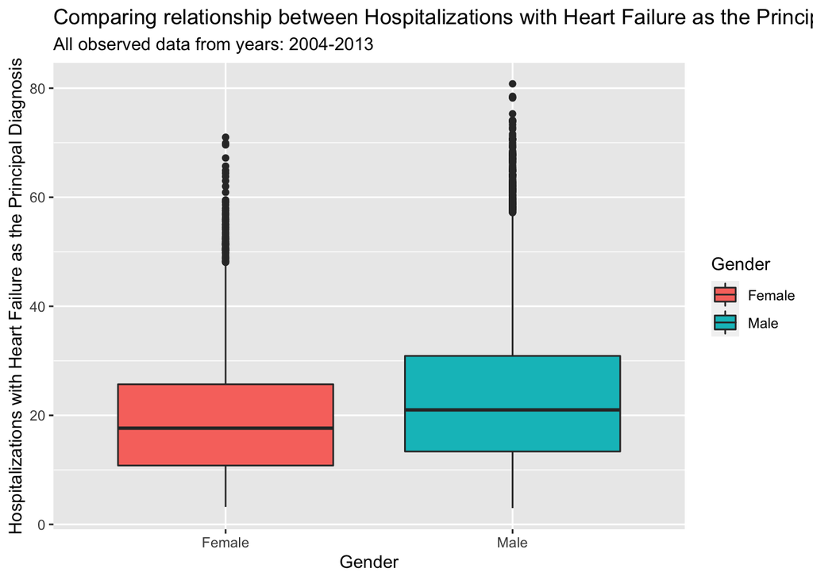

Based on these initial statistics and visualizations depicted above, associations between heart failure hospitalizations and gender can be observed. When observing the box plot visualization comparing Female and Male rates of heart failure hospitalizations using `Data_Value`, for example, we see the median `Data_Value` rate for males is slightly higher on average with a value of 21.00 when compared to a median rate of 17.65 for females; furthermore, the mean `Data_Value` rate for males is around 24.95, and 20.60 for females.

```
## Response: Data_Value (numeric)
## Explanatory: Break_Out (factor)
## # A tibble: 6 × 2
##   replicate  stat
##       <int> <dbl>
## 1         1  4.66
## 2         2  4.25
## 3         3  3.94
## 4         4  4.25
## 5         5  4.60
## 6         6  3.69
```

```
## # A tibble: 1 × 3
##    mean lower upper
##   <dbl> <dbl> <dbl>
## 1  4.34  3.48  5.26
```

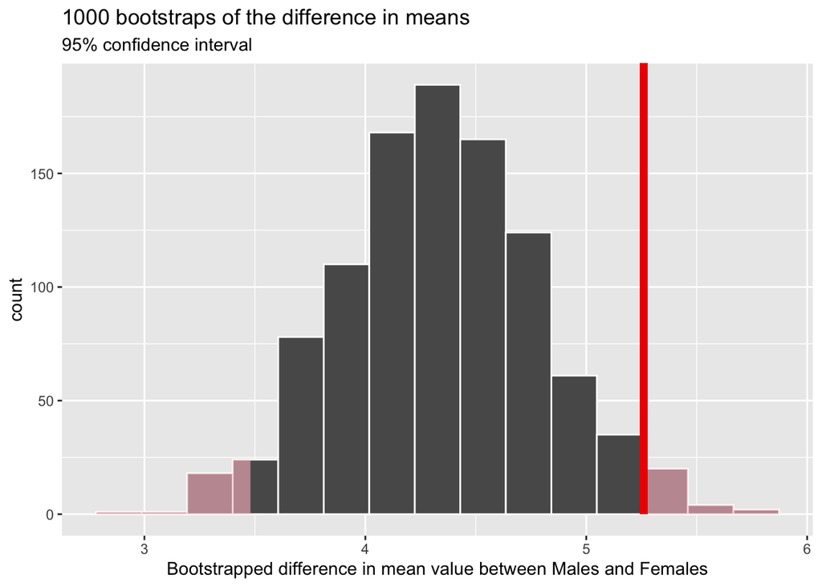

To further analyze the disparity in the mean hospitalization rates, the distribution and frequency of the bootstrapped difference in mean `Data_Value` between males and females can be visualized above. Using calculations, furthermore, the lower and upper bounds of a 95% bootstrap confidence interval are about 3.4801 and 5.2598 respectively. This illustrates that we are 95% confident that the true parameters (average difference in mean value between males and females for hospitalized Medicaid & Medicare patients with Heart Failure as the principal diagnosis in 2004-2013, across the US) is within the random bounds 3.4801 and 5.2598. The 95% confidence interval is also depicted on the histogram by the red vertical line illustrating the upper limit and the red-shaded regions (values outside random bounds 3.4801 and 5.2598). From the collective statistics and visualizations illustrating the relationship between heart failure hospitalizations and gender, observations can be made about the high hospitalization rates for males in respect to females.

Consequently, we can specify our general research question by asking and answering the following:

**Are Males more Susceptible (in comparison to Females) to High Rates of Hospitalizations with Heart Failure as the Principal Diagnosis?**

**Null Hypothesis**: Gender has no influence on a patient’s susceptibility for high rates of heart failure related hospitalizations. Specifically, the variables `Break_Out` (Gender) and `High_Rate` are independent: the difference in proportion between Genders for high rates of heart failure related hospitalizations are equal to 0 (high_rate_proportion Male == high_rate_proportion Female) .

**Alternative Hypothesis**: Gender will influence a patient’s susceptibility for high rates of heart failure related hospitalizations. Specifically, males will be adversely impacted by high rates of heart failure related hospitalizations in proportion to females. The difference in proportion between males and females for high rates of heart failure related hospitalizations are greater than zero (proportion Male>proportion Female).

```
## # A tibble: 2 × 3
##   Break_Out prop_yes prop_no
##   <chr>        <dbl>   <dbl>
## 1 Female      0.0438   0.956
## 2 Male        0.111    0.889
```

```
##   obs_diff
## 0.06682692
```

In this analysis, a bootstrap difference in proportions can be used to gain insights on the null/alternative hypothesis. This method of statistical analysis is appropriate for this research question because it seeks to compare the relationship between two variables (high heart failure rates and gender) and justification for rejecting/failing to reject our null hypothesis. Setting the infrastructure for analysis, a new column (variable) called `High_Rate` can be created which categorizes observations by a boolean expression which denotes whether the rate of heart failure observed was high or not high (“yes”/“no”). `High_Rate` specifically describes whether an observation had a heart failure rate greater than or equal to 50 for gender observations (if `Data_Value` >= 50, `High_Rate` == “yes”). Subsequently, this new variable can be compared with gender to highlight whether the differences in proportion were statistically significant enough to suggest that `High_Rate` and gender are related. Considering the null hypothesis, we assume these variables are unrelated and expect the difference in proportions to equal 0 (equal proportion of High_Rate between gender).

```
## Response: High_Rate (factor)
## Explanatory: Break_Out (factor)
## Null Hypothesis: independence
## # A tibble: 6 × 2
##   replicate      stat
##       <int>     <dbl>
## 1         1  0.00433
## 2         2  0.000481
## 3         3  0.0197
## 4         4  0.00529
## 5         5 -0.00337
## 6         6  0.00240
```

```
## # A tibble: 1 × 3
##        mean   lower  upper
##       <dbl>   <dbl>  <dbl>
## 1 0.0000929 -0.0207 0.0216
```

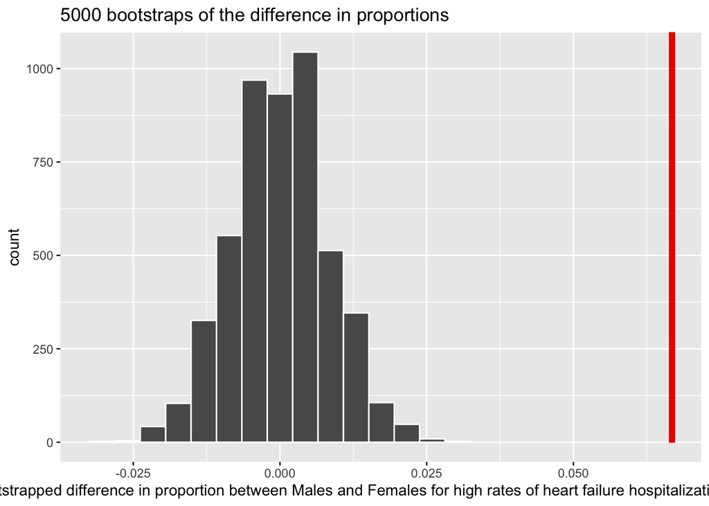

Although observations can be made about the association between gender and heart failure rates based on initial visualizations, it is erroneous to explicitly state a relationship without statistical reasoning. In the analysis comparing gender and high rates of heart failure hospitalizations, consequently, evidence is given to support or refute initial claims. Using bootstrapping and a difference of proportions test, the null hypothesis stating: “gender has no influence on a patient’s susceptibility for high rates of heart failure related hospitalizations” was ultimately rejected due to the p-value being extremely small, which illustrates statistical significant against the null hypothesis. There are still issues pertaining to the validity of our data and analysis, however, as this data frame represents a small proportion (Medicare & Medicaid patients) of the larger U.S demographic. The influence of confounding variables, furthermore, can skew analyses and create unreliable conclusions. In this analysis, for example, the influence of unaccounted predictor variables such as age or ethnicity can create false conclusions. If statistical analysis on this research question were to be reconducted, it is essential to incorporate other unique data sets on cardiovascular disease to see if insights are consistent.

### Is there a relationship between Heart Failure Hospitalizations and Geographical Region of the U.S.?

Here is a preliminary data summary of the data set comparing the relationship between geographic location and different types of heart diseases.

```
## # A tibble: 6 × 7
## # Groups:   Topic [1]
##   Topic   Region  mean_percentage median_percenta… max_percentage min_percentage
##   <chr>   <fct>             <dbl>            <dbl>          <dbl>          <dbl>
## 1 Heart … Midwest            19.9             15.3           333.            1.3
## 2 Heart … Northe…            20.8             16.3           168.            1.1
## 3 Heart … Pacific            15.3             11.8           156.            1.7
## 4 Heart … Rocky …            13.5             10.1           137.            1.4
## 5 Heart … Southe…            22.5             18.7           214.            1
## 6 Heart … southw…            18.2             14.8            93             2.7
## # … with 1 more variable: iqr_percentage <dbl>
```

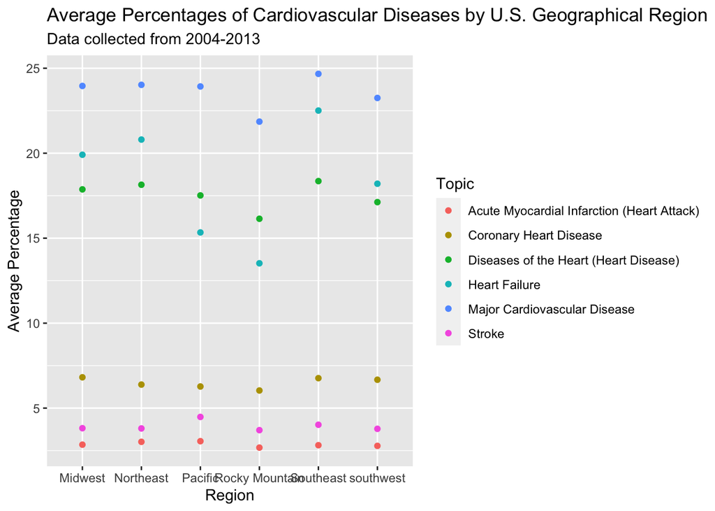

Of the six conditions shown on this preliminary plot, five of them do not appear to have significant variance in average percentages depending on the region of the U.S. the data is sourced from. The only condition that appears to be affected by the region is Heart Failure. As a result of this observation, the rest of this subsection will focus primarily on this apparent relationship between Heart Failure and U.S. geographical region.

**Null Hypothesis: There is no relationship between Heart Failure Hospitalizations and Geographical Region of the U.S.**

**Alternative Hypothesis: There is a relationship between Heart Failure Hospitalizations and Geographical Region of the U.S.**

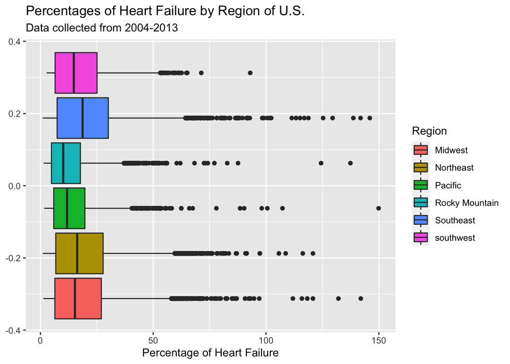

Based on the medians, ranges, and interquartile ranges of the data as shown by the box plots, it would be fair to say that people living in the Southeast region of the United States appear to, on average, have a notably higher percentage of heart failure than those who live in the Rocky Mountain region of the United States. More specifically, the median of 18.7, the IQR of 22.7, and the range of 212.9 for the Southeast Region are all significantly higher than the comparable values of the Rocky Mountain region, which are 10.1, 12.825, and 136, respectively.

```
##   Tukey multiple comparisons of means
##     95% family-wise confidence level
##
## Fit: aov(formula = Data_Value ~ Region, data = cms_hf)
##
## $Region
##                                diff         lwr        upr     p adj
## Northeast-Midwest         0.8929535 -0.09012032  1.8760273 0.0999985
## Pacific-Midwest          -4.5724000 -5.84854604 -3.2962540 0.0000000
## Rocky Mountain-Midwest   -6.3875106 -7.59412081 -5.1809003 0.0000000
## Southeast-Midwest         2.5996555  1.62068605  3.5786250 0.0000000
## southwest-Midwest        -1.7060682 -3.08177929 -0.3303571 0.0054851
## Pacific-Northeast        -5.4653535 -6.74198168 -4.1887254 0.0000000
## Rocky Mountain-Northeast -7.2804641 -8.48758423 -6.0733439 0.0000000
## Southeast-Northeast       1.7067021  0.72710413  2.6863000 0.0000103
## southwest-Northeast      -2.5990217 -3.97518005 -1.2228633 0.0000011
## Rocky Mountain-Pacific   -1.8151105 -3.27087618 -0.3593449 0.0051168
## Southeast-Pacific         7.1720556  5.89858527  8.4455259 0.0000000
## southwest-Pacific         2.8663318  1.26760536  4.4650583 0.0000049
## Southeast-Rocky Mountain  8.9871661  7.78338611 10.1909461 0.0000000
## southwest-Rocky Mountain  4.6814424  3.13765287  6.2252319 0.0000000
## southwest-Southeast      -4.3057237 -5.67895314 -2.9324943 0.0000000
```

```
##                Df  Sum Sq Mean Sq F value Pr(>F)
## Region          5  158260   31652   123.2 <2e-16 ***
## Residuals   18462 4743095     257
## ---
## Signif. codes:  0 '***' 0.001 '**' 0.01 '*' 0.05 '.' 0.1 ' ' 1
```

According to a One-Way Analysis of Variance performed on the data, we can, with 95% confidence, reject the null hypothesis that Heart Failure hospitalizations are not influenced by U.S. Region. This is due specifically to two facts:

1. Of the 15 comparisons made, 14 of them have adjusted p-values that are less than 0.01, meaning that most of these differences are statistically significant.

2. The test gave an F-Value of 123.2, which is far greater than the ~1 necessary to accept the null hypothesis.

Due to the of the results of the one-way analysis of variance, we can reject the null hypothesis, which was that there is no relationship between heart failure hospitalizations and geographical region of the U.S. Instead, we can accept the alternative hypothesis, which was that there is indeed a strong relationships between heart failure hospitalizations and U.S. geographical region. More specifically, this choice is evidenced by the majority of adjusted p-values being statistically significant (14/15 are less than 0.01), as well as the f-value being far greater than 1 (123.2). However, although the data set used was rather large, if this test were to be reperformed in order to ensure or enhance the validity of the results, it is important that a different population of U.S. residents be used, as that would help prove that these findings are not based on coincidence.

### Does Age influence the prevalence of Cardiovascular Disease among Hospitalizations?

Here is a starting data summary of the data set comparing the relationship between age and different types of heart diseases

```
## # A tibble: 12 × 8
## # Groups:   Topic [6]
##    Topic    Age   mean_percentage median_percenta… max_percentage min_percentage
##    <chr>    <chr>           <dbl>            <dbl>          <dbl>          <dbl>
##  1 Acute M… 65+              2.87              2.8            4.8            1.5
##  2 Coronar… 65+              7.77              7.6           12.4            3.8
##  3 Disease… 65+             17.5              17.4           23.3           12
##  4 Heart F… 65+              3.91              3.9            7.1            2.1
##  5 Major C… 65+             23.2              23.1           29.2           17
##  6 Stroke   65+              3.41              3.4            4.4            2.4
##  7 Acute M… 75+              2.88              2.8            5.1            1.9
##  8 Coronar… 75+              5.80              5.7            9.6            2.9
##  9 Disease… 75+             18.4              18.4           22.5           14.4
## 10 Heart F… 75+              5.98              6              7.8            4.1
## 11 Major C… 75+             24.4              24.3           28.6           19.8
## 12 Stroke   75+              4.11              4.1            5.7            3.2
## # … with 2 more variables: sd_percentage <dbl>, iqr_percentage <dbl>
```

Looking at the mean and median values for each disease topic and two age groups, the difference between demographics and outliers are minimal in this cardiovascular disease data set. However, in the age 65+ group with Major Cardiovascular Diseases, there was the greatest standard deviation and IQR among other diseases in all age group. Therefore, the observations for this sample is more spread out compared to other diseases (eg. Stroke).

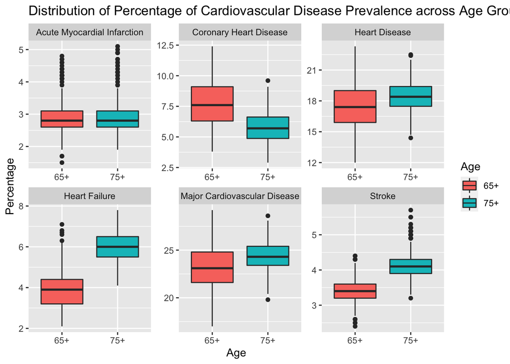

From the graphs, we can see that there is a relationship between age and heart diseases. For most type of heart diseases displayed in the graphs, the 75+ age group have a higher percentage of having different types of heart diseases except for coronary heart diseases. From the spread and shape of the box plots, the age group of 65+ generally have a larger data spread than the age group of 75+. From this perspective, we can also see that the age group of 75+ have a more concentrated spread and higher than the group of age 65+. In this sense, the age group of 75+ generally have higher percentage samples than the group of age 65+, except for Coronary Heart Disease; the age group of 65+ have larger spread over in higher percentages than the age group of 75+. On the other hand, the age group of 75+ have a significant higher percentage with slightly smaller spread in Heart Failure than the age group of 65+.

```
## # A tibble: 7 × 5
##   term                                    estimate std.error statistic   p.value
##   <chr>                                      <dbl>     <dbl>     <dbl>     <dbl>
## 1 (Intercept)                                2.63     0.0482      54.6 0
## 2 TopicCoronary Heart Disease                3.91     0.0631      61.9 0
## 3 TopicDiseases of the Heart (Heart Dise…   15.1      0.0631     239.  0
## 4 TopicHeart Failure                         2.07     0.0631      32.7 3.79e-217
## 5 TopicMajor Cardiovascular Disease         20.9      0.0631     332.  0
## 6 TopicStroke                                0.885    0.0631      14.0 5.73e- 44
## 7 Age75+                                     0.488    0.0365      13.4 2.62e- 40
```

Linear effects model for age and prevalence (%) of cardiovascular disease among hospitalizations:

*Prevalence (%) of Cardiovascular Heart Disease among Hospitalizations= 2.634 + Coronary Heart Disease * 3.906 + Diseases of the Heart * 15.069 + Heart Failure * 2.067 + Major Cardiovascular Disease * 20.930 + Stroke * 0.885 + Age 75+ * 0.488*

The baseline for this model is Acute Myocardial Infarction (Heart Attack) and age 65+, and this model means, when there is no other diseases except for Acute Myocardial Infarction, the percentage of people from age group of 65+, will be about 2.634. When Coronary Heart Disease is true (value of 1), the percentage will add by 3.906 on top of 2.634 baseline value. If Disease of the Heart is true, the percentage will add 15.069 on top of 2.634. If Heart Failure is true, the percentage will add 2.067 on top of 2.634. If Major Cardiovascular Disease is true, the percentage will add 20.930 on top of 2.634. If Stroke is true, the percentage will add 0.885 on top of 2.634. Lastly, if the observed patient is in the age group of 75+, the percentage will add 0.488 on top of 2.634; although it is a minor change, being in the 75+ age group increases the likelihood of cardiovascular disease prevalence for all hospitalizations by 0.488 percent on average.

```
## # A tibble: 1 × 1
##   adj.r.squared
##           <dbl>
## 1         0.968
```

Splitting the age_comparison data into a training set with the size of 70% and a test set with the size of 30%, we get marginally different computations in comparison to the original linear effects model. The adjusted r squared for this training model is 0.9682052, in this case, about 96.8% of the data from age and cardiovascular heart diseases is explained by the linear model. Furthermore, the predicted rmse value for the split data frame is rmse, standard, 1.4403688, which is relatively low and illustrates that age and topics are good predictors for percent composition of cardiovascular disease prevalence among hospitalizations.

Since the adjusted r squared of the linear effects model shows that our linear model is significant, we can tell that different types of cardiovascular diseases have varying impacts on the prevalence of cardiovascular disease among hospitalized patients. Comparing with all the diseases, however, the impact of age demographics (65+ vs. 75+) on the percentage of people having cardiovascular diseases will be relatively insignificant compared to others. Even though it shows that there isn’t a strong relationship between age and cardiovascular disease prevalence, there are not enough samples from other age groups to tell us the true impacts of age on cardiovascular disease prevalence. So from this data set, it isn’t sufficient for us to get to a conclusion if there is an actual relationship between age and prevalence of cardiovascular diseases among hospitalizations.

## Conclusion

From the collective statistical analyses of our proposed research questions, our understanding of the relationship between predictor variables and susceptibility for cardiovascular disease has furthered. Whether it was rejecting null hypotheses through testing statistical significance or observing the numerical effects of predictors, we have a greater understanding of the influences a variable can have on the underlying issue of cardiovascular disease hospitalizations. In terms of critiques and suggestions, a consensus was made that our data set was not representative of the larger U.S. population and subsequent statistical conclusions were not concrete. Furthermore, we agreed that cross-referencing data sets would lead to increased accuracy of our findings and provide further justifications for relationships between predictor variables and cardiovascular disease related hospitalizations. If analysis on this issue were to be conducted again, it is essential to incorporate diverse data sets with differing demographics and variables to truly gather insights on this critical issue.